# The Olympic Games project

Anastasia Tokareva

07.11.2021

### 0. Install all the libraries needed

```r
library(dplyr)
library(readr)
library(ggplot2)
```

### 1. Select and bind the data from different data frames

The data is divided into different files, which must have the same format and be stored in the same folder. At first, we need to merge this files to one data frame. You can change path to your own variant or store csv files in ‘../data/’ directory:

```r
data_all <- list.files(path = "../data/",
                       pattern = "*.csv",
                       full.names = TRUE) %>%
  lapply(read_csv) %>%
  bind_rows
```

### 2. Check if the data is correct (are there any NA or invalid values)

We can use ‘str’ command to observe information about the dataframe:

```r
str(data_all)
```

```
## spec_tbl_df [271,115 x 15] (S3: spec_tbl_df/tbl_df/tbl/data.frame)
##  $ ID    : num [1:271115] 1 2 3 4 5 5 5 5 5 5 ...
##  $ Name  : chr [1:271115] "A Dijiang" "A Lamusi" "Gunnar Nielsen Aaby" "Edgar Lindenau Aabye" ...
##  $ Sex   : chr [1:271115] "M" "M" "M" "M" ...
##  $ Age   : num [1:271115] 24 23 24 34 21 21 25 25 27 27 ...
##  $ Height: num [1:271115] 180 170 NA NA 185 185 185 185 185 185 ...
##  $ Weight: num [1:271115] 80 60 NA NA 82 82 82 82 82 82 ...
##  $ Team  : chr [1:271115] "China" "China" "Denmark" "Denmark/Sweden" ...
##  $ NOC   : chr [1:271115] "CHN" "CHN" "DEN" "DEN" ...
##  $ Games : chr [1:271115] "1992 Summer" "2012 Summer" "1920 Summer" "1900 Summer" ...
##  $ Year  : num [1:271115] 1992 2012 1920 1900 1988 ...
##  $ Season: chr [1:271115] "Summer" "Summer" "Summer" "Summer" ...
##  $ City  : chr [1:271115] "Barcelona" "London" "Antwerpen" "Paris" ...
##  $ Sport : chr [1:271115] "Basketball" "Judo" "Football" "Tug-Of-War" ...
##  $ Event : chr [1:271115] "Basketball Men's Basketball" "Judo Men's Extra-Lightweight" "Football Men's Football" "Tug-Of-War Men's Tug-Of-War" ...
##  $ Medal : chr [1:271115] NA NA NA "Gold" ...
##  - attr(*, "spec")=
##   .. cols(
##   ..   ID = col_double(),
##   ..   Name = col_character(),
##   ..   Sex = col_character(),
##   ..   Age = col_double(),
##   ..   Height = col_double(),
##   ..   Weight = col_double(),
##   ..   Team = col_character(),
##   ..   NOC = col_character(),
##   ..   Games = col_character(),
##   ..   Year = col_double(),
##   ..   Season = col_character(),
##   ..   City = col_character(),
##   ..   Sport = col_character(),
##   ..   Event = col_character(),
##   ..   Medal = col_character()
##   .. )
##  - attr(*, "problems")=<externalptr>
```

Firstly, we need to deal with invalid values:

#### ‘Sex’ variable

This variable has ‘chr’ type and can possibly include ‘F’, ‘M’ or NA values. Therefore, we need to find observations that do not fulfill this condition:

```r
data_all %>% filter(!(Sex %in% c('F', 'M', NA)))
```

```
## # A tibble: 2 x 15
##      ID Name    Sex     Age Height Weight Team    NOC   Games  Year Season City
##   <dbl> <chr>   <chr> <dbl>  <dbl>  <dbl> <chr>   <chr> <chr> <dbl> <chr>  <chr>
## 1 79609 Pavel ~ G        22    182     79 Czecho~ TCH   1972~  1972 Summer Muni~
## 2 79630 Anatol~ G        37     NA     NA Russia  RUS   1996~  1996 Summer Atla~
## # ... with 3 more variables: Sport <chr>, Event <chr>, Medal <chr>
```

Pavel Mike and Anatoly Mikhaylin have ‘G’ in the sex column. Considering the fact that these are male names, we can change it to ‘M’.

```r
data_all <- data_all %>% mutate(Sex = ifelse(Name == 'Pavel Mike', 'M', Sex))
data_all <- data_all %>% mutate(Sex = ifelse(Name == 'Anatoly Mikhaylin', 'M', Sex))
```

We also noticed that for some participants there are more than 1 observation in a data frame, for the reason that some people participated in the Olympics several times. Considering that, we can use information from 1 observation to fill the gaps in another.

```r
data_all %>% filter(Sex %in% c(NA))
```

```
## # A tibble: 2 x 15
##       ID Name     Sex     Age Height Weight Team  NOC   Games  Year Season City
##    <dbl> <chr>    <chr> <dbl>  <dbl>  <dbl> <chr> <chr> <chr> <dbl> <chr>  <chr>
## 1 113716 Pietro ~ <NA>     NA     NA     NA <NA>  <NA>  <NA>     NA <NA>   <NA>
## 2 124516 <NA>     <NA>     NA     NA     NA <NA>  <NA>  <NA>     NA <NA>   <NA>
## # ... with 3 more variables: Sport <chr>, Event <chr>, Medal <chr>
```

2 people with ID’s 113716, 124516 were found.

```r
data_all %>% filter(ID %in% c(113716, 124516))
```

```
## # A tibble: 5 x 15
##       ID Name    Sex     Age Height Weight Team  NOC   Games   Year Season City
##    <dbl> <chr>   <chr> <dbl>  <dbl>  <dbl> <chr> <chr> <chr>  <dbl> <chr>  <chr>
## 1 113716 Pietro~ M        31     NA     NA Italy ITA   1908 ~  1908 Summer Lond~
## 2 113716 Pietro~ <NA>     NA     NA     NA <NA>  <NA>  <NA>      NA <NA>   <NA>
## 3 113716 Pietro~ M        43     NA     NA Italy ITA   1920 ~  1920 Summer Antw~
## 4 113716 Pietro~ M        43     NA     NA Italy ITA   1920 ~  1920 Summer Antw~
## 5 124516 <NA>    <NA>     NA     NA     NA <NA>  <NA>  <NA>      NA <NA>   <NA>
## # ... with 3 more variables: Sport <chr>, Event <chr>, Medal <chr>
```

```r
data_all <- data_all %>% mutate(Sex = ifelse(ID == '113716', 'M', Sex))
```

#### ‘Age’ variable

```r
data_all %>% filter(Age %in% c(NA))
```

```
## # A tibble: 9,476 x 15
##       ID Name    Sex     Age Height Weight Team   NOC   Games  Year Season City
##    <dbl> <chr>   <chr> <dbl>  <dbl>  <dbl> <chr>  <chr> <chr> <dbl> <chr>  <chr>
##  1    54 "Moham~ M        NA     NA     NA Iran   IRI   1948~  1948 Summer Lond~
##  2    58 "Georg~ M        NA     NA     NA Bulga~ BUL   1924~  1924 Summer Paris
##  3    58 "Georg~ M        NA     NA     NA Bulga~ BUL   1924~  1924 Summer Paris
##  4    66 "Moham~ M        NA    156     48 Sudan  SUD   1972~  1972 Summer Muni~
##  5   102 "Sayed~ M        NA     NA     NA Egypt  EGY   1920~  1920 Summer Antw~
##  6   102 "Sayed~ M        NA     NA     NA Egypt  EGY   1928~  1928 Summer Amst~
##  7   133 "Franz~ M        NA     NA     NA Germa~ GER   1900~  1900 Summer Paris
##  8   139 "Georg~ M        NA     NA     NA Thess~ GRE   1906~  1906 Summer Athi~
##  9   163 "Ismai~ M        NA     NA     NA Unite~ UAR   1960~  1960 Summer Roma
## 10   163 "Ismai~ M        NA     NA     NA Unite~ UAR   1960~  1960 Summer Roma
## # ... with 9,466 more rows, and 3 more variables: Sport <chr>, Event <chr>,
## #   Medal <chr>
```

The amount of NA’s was too vast (9,476) to consider changing it manually. However, the proportion of observations with NA’s in Age variable was only 3,5%, so we decided to leave it without changes. There might be different approaches to this problem. But I decided that this 3,5% lack of information is not significant enough to cause any problems later.

The all-time record for the oldest Olympics competitor was 72 years, whereas the youngest competitor was 10 years old.

```r
data_all %>% filter(Age > 72)
```

```
## # A tibble: 45 x 15
##       ID Name    Sex     Age Height Weight Team   NOC   Games  Year Season City
##    <dbl> <chr>   <chr> <dbl>  <dbl>  <dbl> <chr>  <chr> <chr> <dbl> <chr>  <chr>
##  1  4160 Robert~ M        75     NA     NA Unite~ USA   1932~  1932 Summer Los ~
##  2  5146 George~ M        84     NA     NA Great~ GBR   1948~  1948 Summer Lond~
##  3 10220 Frank ~ M        74     NA     NA Unite~ USA   1936~  1936 Summer Berl~
##  4 18252 Anne M~ F        73     NA     NA Denma~ DEN   1936~  1936 Summer Berl~
##  5 22984 John (~ M        73     NA     NA Great~ GBR   1948~  1948 Summer Lond~
##  6 22984 John (~ M        73     NA     NA Great~ GBR   1948~  1948 Summer Lond~
##  7 23459 Flicie~ M       240     NA     NA Belgi~ BEL   1912~  1912 Summer Stoc~
##  8 27972 Godefr~ M        74     NA     NA Belgi~ BEL   1936~  1936 Summer Berl~
##  9 27972 Godefr~ M        74     NA     NA Belgi~ BEL   1936~  1936 Summer Berl~
## 10 27972 Godefr~ M        74     NA     NA Belgi~ BEL   1936~  1936 Summer Berl~
## # ... with 35 more rows, and 3 more variables: Sport <chr>, Event <chr>,
## #   Medal <chr>
```

We googled several names from the list and found out, that they are sculptors and artists, not sportsmen. Finally, the decision was made to replace this values with NA, so that our research would not include ages of 73 or above.

```r
data_all <- data_all %>% mutate(Age = ifelse(Age > 72, NA, Age))
```

In the next step we check if some of the competitors on the list are too young:

```r
data_all %>% filter(Age < 10)
```

```
## # A tibble: 0 x 15
## # ... with 15 variables: ID <dbl>, Name <chr>, Sex <chr>, Age <dbl>,
## #   Height <dbl>, Weight <dbl>, Team <chr>, NOC <chr>, Games <chr>, Year <dbl>,
## #   Season <chr>, City <chr>, Sport <chr>, Event <chr>, Medal <chr>
```

No competitors younger than 10 were found.

#### ‘Height’ variable

```r
data_all %>% filter(Height %in% c(NA))
```

```
## # A tibble: 60,172 x 15
##       ID Name    Sex     Age Height Weight Team   NOC   Games  Year Season City
##    <dbl> <chr>   <chr> <dbl>  <dbl>  <dbl> <chr>  <chr> <chr> <dbl> <chr>  <chr>
##  1     3 "Gunna~ M        24     NA     NA Denma~ DEN   1920~  1920 Summer Antw~
##  2     4 "Edgar~ M        34     NA     NA Denma~ DEN   1900~  1900 Summer Paris
##  3    10 "Einar~ M        26     NA     NA Finla~ FIN   1952~  1952 Summer Hels~
##  4    15 "Arvo ~ M        22     NA     NA Finla~ FIN   1912~  1912 Summer Stoc~
##  5    15 "Arvo ~ M        22     NA     NA Finla~ FIN   1912~  1912 Summer Stoc~
##  6    15 "Arvo ~ M        30     NA     NA Finla~ FIN   1920~  1920 Summer Antw~
##  7    15 "Arvo ~ M        30     NA     NA Finla~ FIN   1920~  1920 Summer Antw~
##  8    15 "Arvo ~ M        34     NA     NA Finla~ FIN   1924~  1924 Summer Paris
##  9    19 "Win V~ M        54     NA     NA Finla~ FIN   1948~  1948 Summer Lond~
## 10    24 "Nils ~ M        24     NA     NA Norway NOR   1960~  1960 Winter Squa~
## # ... with 60,162 more rows, and 3 more variables: Sport <chr>, Event <chr>,
## #   Medal <chr>
```

The amount of NA’s in Height variable equaled 60,172 and was significant enough. However, it would take too much time to replace them with values manually, and by replacing them with a mean value, we would make an assumption, that height does not depend on sex, age, sport and nationality. But that is not true. For that reason we decided to leave these NA’s without any changes.

#### ‘Weight’ variable

```r
data_all %>% filter(Weight %in% c(NA))
```

```
## # A tibble: 62,876 x 15
##       ID Name    Sex     Age Height Weight Team   NOC   Games  Year Season City
##    <dbl> <chr>   <chr> <dbl>  <dbl>  <dbl> <chr>  <chr> <chr> <dbl> <chr>  <chr>
##  1     3 "Gunna~ M        24     NA     NA Denma~ DEN   1920~  1920 Summer Antw~
##  2     4 "Edgar~ M        34     NA     NA Denma~ DEN   1900~  1900 Summer Paris
##  3     8 "Corne~ F        18    168     NA Nethe~ NED   1932~  1932 Summer Los ~
##  4     8 "Corne~ F        18    168     NA Nethe~ NED   1932~  1932 Summer Los ~
##  5    10 "Einar~ M        26     NA     NA Finla~ FIN   1952~  1952 Summer Hels~
##  6    15 "Arvo ~ M        22     NA     NA Finla~ FIN   1912~  1912 Summer Stoc~
##  7    15 "Arvo ~ M        22     NA     NA Finla~ FIN   1912~  1912 Summer Stoc~
##  8    15 "Arvo ~ M        30     NA     NA Finla~ FIN   1920~  1920 Summer Antw~
##  9    15 "Arvo ~ M        30     NA     NA Finla~ FIN   1920~  1920 Summer Antw~
## 10    15 "Arvo ~ M        34     NA     NA Finla~ FIN   1924~  1924 Summer Paris
## # ... with 62,866 more rows, and 3 more variables: Sport <chr>, Event <chr>,
## #   Medal <chr>
```

The amount of NA’s in Weight variable was highly significant as well at exactly 62,876 observations. But for the same reason (as for height) we decided to leave these NA’s without any changes.

#### ‘Sport’ variable

We summarized information about sport:

```r
data_all %>% group_by(Sport) %>% summarise()
```

```
## # A tibble: 68 x 1
##    Sport
##    <chr>
##  1 Aeronautics
##  2 Alpine Skiing
##  3 Alpinism
##  4 Archery
##  5 Art Competitions
##  6 Athletics
##  7 Badminton
##  8 Baseball
##  9 Basketball
## 10 Basque Pelota
## # ... with 58 more rows
```

A problem were found with football, because in the data frame were name “Footba” as well. We changed it:

```r
data_all <- data_all %>%
  mutate(Sport = ifelse(Sport == "Footba", 'Football', Sport))
```

#### ‘Event’ variable

We summarized information about the events:

```r
data_all %>% group_by(Event) %>% summarise()
```

```
## # A tibble: 767 x 1
##    Event
##    <chr>
##  1 Aeronautics Mixed Aeronautics
##  2 Alpine Skiing Men's Combined
##  3 Alpine Skiing Men's Downhill
##  4 Alpine Skiing Men's Giant Slalom
##  5 Alpine Skiing Men's Slalom
##  6 Alpine Skiing Men's Super G
##  7 Alpine Skiing Women's Combined
##  8 Alpine Skiing Women's Downhill
##  9 Alpine Skiing Women's Giant Slalom
## 10 Alpine Skiing Women's Slalom
## # ... with 757 more rows
```

It is quite difficult to search for any invalid values, so we decided to leave this column. The same approach was chosen for variables Team, NOC, City, Year, Name.

#### ‘Season’ variable

```r
data_all %>% filter(!(Season %in% c('Summer', 'Winter', NA)))
```

```
## # A tibble: 0 x 15
## # ... with 15 variables: ID <dbl>, Name <chr>, Sex <chr>, Age <dbl>,
## #   Height <dbl>, Weight <dbl>, Team <chr>, NOC <chr>, Games <chr>, Year <dbl>,
## #   Season <chr>, City <chr>, Sport <chr>, Event <chr>, Medal <chr>
```

No invalid values.

#### ‘Medal’ variable

```r
data_all %>% filter(!(Medal %in% c('Gold', 'Silver', 'Bronze', NA)))
```

```
## # A tibble: 0 x 15
## # ... with 15 variables: ID <dbl>, Name <chr>, Sex <chr>, Age <dbl>,
## #   Height <dbl>, Weight <dbl>, Team <chr>, NOC <chr>, Games <chr>, Year <dbl>,
## #   Season <chr>, City <chr>, Sport <chr>, Event <chr>, Medal <chr>
```

Everything is OK with this column.

### 3. Identifying the age of the youngest male and female sportsmen in the 1992 Olympic Games

```r
the_youngest_male_1992 <- data_all %>% filter(Year == 1992 & Sex == 'M') %>% filter(Age == min(Age, na.rm = TRUE))
the_youngest_female_1992<- data_all %>% filter(Year == 1992 & Sex == 'F') %>% filter(Age == min(Age, na.rm = TRUE))
```

The youngest female competitor in 1992 was Judit Kiss at the age of 12, and the youngest male competitor in 1992 was Carlos Bienvenido Front Barrera at the age of 11.

### 4. Average and standard deviation of the ‘Height’ variable for male and female competitors

```r
average_sd_height <- data_all %>% group_by(Sex) %>% select(Height) %>%
  summarise(across(.f = list(mean = mean, sd = sd), na.rm = T))
```

average for females = 167.842 sd for females = 8.80343

average for males = 178.859 sd for males = 9.36034

### 5. Average and standard deviation for ‘Height’ variable for females who played tennis on the Olympics in 2000 (round)

```r
average_female_tennis_2000 <- data_all %>%
  filter(Sex == 'F', Year == 2000, Sport == 'Tennis') %>%
  summarise(mean(Height, na.rm = TRUE))
average_female_tennis_2000 <- round(average_female_tennis_2000[1,1], digits = 1)
sd_female_tennis_2000 <- data_all %>%
  filter(Sex == 'F', Year == 2000, Sport == 'Tennis') %>%
  summarise(sd(Height, na.rm = TRUE))
sd_female_tennis_2000 <- round(sd_female_tennis_2000[1,1], digits = 1)
```

average = 171.8 sd = 6.5

### 6. Identifying the spors type of the heaviest competitor in 2006

```r
the_heaviest_competitor_2006 <- data_all %>%
  filter(Year == 2006) %>%
  filter(Weight == max(Weight, na.rm = TRUE))
```

The heaviest competitor in 2006 was Patrick R. Antaki with a weight of 127kg, he participated in Skeleton (Men’s Skeleton).

### 7. The number of Golden medals won by females between 1980 and 2010

```r
golden_females_1980_2010 <- nrow(data_all %>%
  filter(Sex == 'F' & (Year >= 1980 & Year <= 2010) & Medal == 'Gold'))
```

Between 1980 and 2010 female competitors won 2249 Golden medals.

### 8. How many times have John Aalberg participated in the Olympics (in different years)

```r
john_aalberg <- data_all %>% filter(Name == 'John Aalberg')
john_aalberg_times <- nrow(john_aalberg)
john_aalberg_years <- unique(select(john_aalberg, Year))
```

John Aalberg participated in the Olympic Games 8 times, in 1992 and 1994.

The age groups: [15-25), [25-35), [35-45), [45-55]

```r
age_groups <- table(cut(data_all$Age, seq(15, 55, by=10), left = T, right=F, include.lowest=T))
age_groups
```

```
##
## [15,25) [25,35) [35,45) [45,55]
##  130056  110989   15110    3377
```

The biggest age group is [15-25), consisting of 130056 competitors, and the smallest one is [45,55], containing only 3377 competitors.

### 10. To what extense the number of sports changed between 1994 and 2002

```r
sports_1994 <- unique(data_all %>% filter(Year == '1994') %>% select(Sport))
sports_2002 <- unique(data_all %>% filter(Year == '2002') %>% select(Sport))
change_between_1994_and_2002 <- nrow(sports_1994) - nrow(sports_2002)
```

Between 1994 and 2002 the number of sports increased by 3.

### 11. Top-3 countries for each season and for each type of medals

Considering the fact that several teams in a data frame may represent 1 country, it is better to group by NOC(National Olympic Committees).

Winter:

```r
gold_winter <- data_all %>%
  filter(Medal == 'Gold' & Season == 'Winter') %>%
  group_by(NOC) %>%
  summarise(Count = n()) %>%
  arrange(-Count) %>%
  slice_head(n = 3)

silver_winter <- data_all %>%
  filter(Medal == 'Silver' & Season == 'Winter') %>%
  group_by(NOC) %>%
  summarise(Count = n()) %>%
  arrange(-Count) %>%
  slice_head(n = 3)

bronze_winter <- data_all %>%
  filter(Medal == 'Bronze' & Season == 'Winter') %>%
  group_by(NOC) %>%
  summarise(Count = n()) %>%
  arrange(-Count) %>%
  slice_head(n = 3)

gold_winter
```

```
## # A tibble: 3 x 2
##   NOC   Count
##   <chr> <int>
## 1 CAN     305
## 2 URS     250
## 3 USA     166
```

```r
silver_winter
```

```
## # A tibble: 3 x 2
##   NOC   Count
##   <chr> <int>
## 1 USA     308
## 2 CAN     199
## 3 NOR     165
```

```r
bronze_winter
```

```
## # A tibble: 3 x 2
##   NOC   Count
##   <chr> <int>
## 1 FIN     215
## 2 SWE     177
## 3 USA     161
```

Top-3 countries in winter: a)Golden: 1)Canada (305) 2)USSR (250) 3)USA (166) b)Silver: 1)USA (308) 2)Canada (199) 3)Norway (165) c)Bronze: 1)Finland (215) 2)Sweden(177) 3)USA (161)

Summer:

```r
gold_summer <- data_all %>%
  filter(Medal == 'Gold' & Season == 'Summer') %>%
  group_by(NOC) %>%
  summarise(Count = n()) %>%
  arrange(-Count) %>%
  slice_head(n = 3)

silver_summer <- data_all %>%
  filter(Medal == 'Silver' & Season == 'Summer') %>%
  group_by(NOC) %>%
  summarise(Count = n()) %>%
  arrange(-Count) %>%
  slice_head(n = 3)

bronze_summer <- data_all %>%
  filter(Medal == 'Bronze' & Season == 'Summer') %>%
  group_by(NOC) %>%
  summarise(Count = n()) %>%
  arrange(-Count) %>%
  slice_head(n = 3)

gold_summer
```

```
## # A tibble: 3 x 2
##   NOC   Count
##   <chr> <int>
## 1 USA    2472
## 2 URS     832
## 3 GBR     636
```

```r
silver_summer
```

```
## # A tibble: 3 x 2
##   NOC   Count
##   <chr> <int>
## 1 USA    1333
## 2 GBR     729
## 3 URS     635
```

```r
bronze_summer
```

```
## # A tibble: 3 x 2
##   NOC   Count
##   <chr> <int>
## 1 USA    1197
## 2 GER     649
## 3 GBR     620
```

Top-3 countries in summer: a)Golden: 1)USA (2472) 2)USSR (832) 3)Great Britain (636) b)Silver: 1)USA (1333) 2)Great Britain (729) 3)USSR (635) c)Bronze: 1)USA (1197) 2)Germany (649) 3)Great Britain (620)

### 12. Create new variable ‘Height_z_scores’ (height standartization)

```r
data_all$Height_z_scores <- scale(data_all$Height)
```

### 13. Min/Max normalization

```r
min_max_normalization <- function(x) {
  (x - min(x, na.rm = TRUE)) / (max(x, na.rm = TRUE) - min(x, na.rm = TRUE))
}
data_all$Height_min_max_normalized <- min_max_normalization(data_all$Height)
```

### 14. Height, Weight and Age comparison for males and females in the Olympic Games in winter

At first, we created 2 new data frames for male and female competitors in winter:

```r
males_winter <- data_all %>%
  filter(Season == 'Winter' & Sex == 'M') %>%
  select(Height, Weight, Age)
females_winter <- data_all %>%
  filter(Season == 'Winter' & Sex == 'F') %>%
  select(Height, Weight, Age)
```

#### Height comparison

Normality tests (work only for 3-5000 values, therefore we needed to create a slice):

```r
shapiro.test(males_winter$Height[0:5000])
```

```
##
##  Shapiro-Wilk normality test
##
## data:  males_winter$Height[0:5000]
## W = 0.99437, p-value = 3.75e-11
```

```r
shapiro.test(females_winter$Height[0:5000])
```

```
##
##  Shapiro-Wilk normality test
##
## data:  females_winter$Height[0:5000]
## W = 0.99509, p-value = 4.517e-11
```

1)W = 0.9944, p-value = 3.75e-11 2)W = 0.9951, p-value = 4.52e-11

Therefore, according to Shapiro-Wilk normality test, the distribution is not normal. Nevertheless, the results might be incorrect, according to the fact that we processed not the whole data frame.

Q-Q plots were drawn to check the normality:

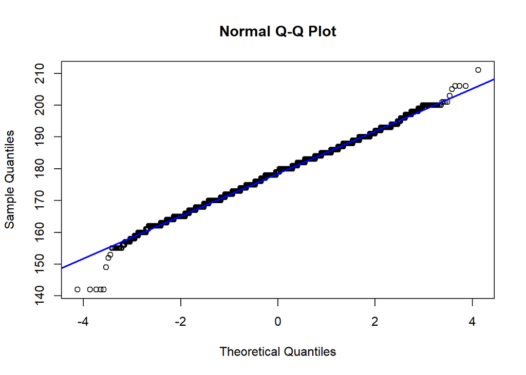

```r
qqnorm(males_winter$Height)
qqline(males_winter$Height, col = "blue", lwd = 2)
```

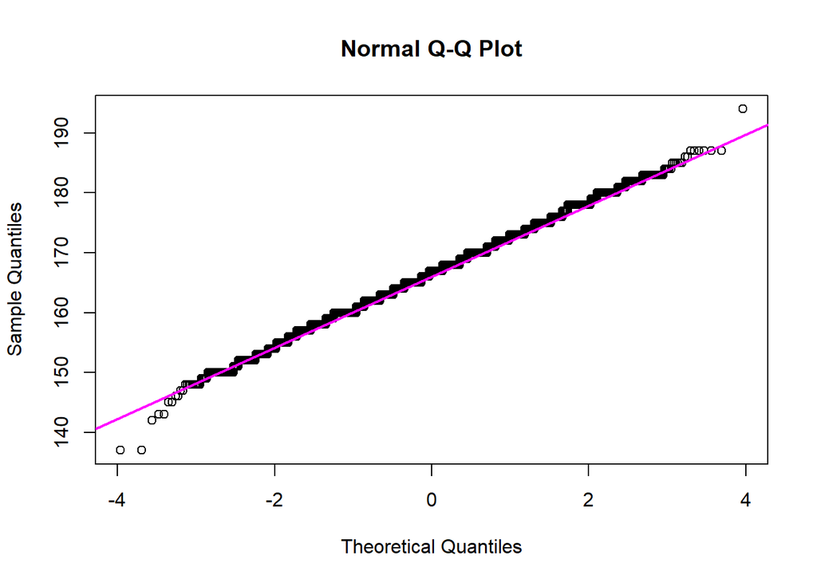

```r
qqnorm(females_winter$Height)
qqline(females_winter$Height, col = "magenta", lwd = 2)
```

The distribution was considered normal in both cases.

Used F test to compare two variances:

```r
var.test(females_winter$Height, males_winter$Height)
```

```
##
##  F test to compare two variances
##
## data:  females_winter$Height and males_winter$Height
## F = 0.8394, num df = 13522, denom df = 26726, p-value < 2.2e-16
## alternative hypothesis: true ratio of variances is not equal to 1
## 95 percent confidence interval:
##  0.8152594 0.8643790
## sample estimates:
## ratio of variances
##          0.8394003
```

F = 0.8394, num df = 13522, denom df = 26726, p-value <2e-16

Therefore, there is a statistically significant difference between variances, and we need to use Welch Two Sample t-test. Firstly, we used two-sided t-test:

```r
t.test(x=females_winter$Height, y=males_winter$Height, alternative = c("two.sided"), var.equal = FALSE)
```

```
##
##  Welch Two Sample t-test
##
## data:  females_winter$Height and males_winter$Height
## t = -184.8, df = 29342, p-value < 2.2e-16
## alternative hypothesis: true difference in means is not equal to 0
## 95 percent confidence interval:
##  -12.26962 -12.01208
## sample estimates:
## mean of x mean of y
##  166.5283  178.6691
```

t = -184.8, df = 29342, p-value <2e-16

The differences are statistically significant (p-value is below the chosen threshold of 0.05), therefore we can reject the null hypothesis (‘There is no difference between males and females height’) in favor of the alternative hypothesis (‘There is a statistically significant difference between males and females height’)

Secondly, we used one-tailed t-test:

```r
t.test(x=females_winter$Height, y=males_winter$Height, alternative = c("less"), var.equal = FALSE)
```

```
##
##  Welch Two Sample t-test
##
## data:  females_winter$Height and males_winter$Height
## t = -184.8, df = 29342, p-value < 2.2e-16
## alternative hypothesis: true difference in means is less than 0
## 95 percent confidence interval:
##       -Inf -12.03278
## sample estimates:
## mean of x mean of y
##  166.5283  178.6691
```

t = -184.8, df = 29342, p-value <2e-16

Again, the differences are statistically significant (p-value is below the chosen threshold of 0.05), therefore we can reject the null hypothesis (‘There is no difference between males and females height’) in favor of the alternative hypothesis (‘Males are generally higher than females’)

Boxplot was drawn to visualize the information:

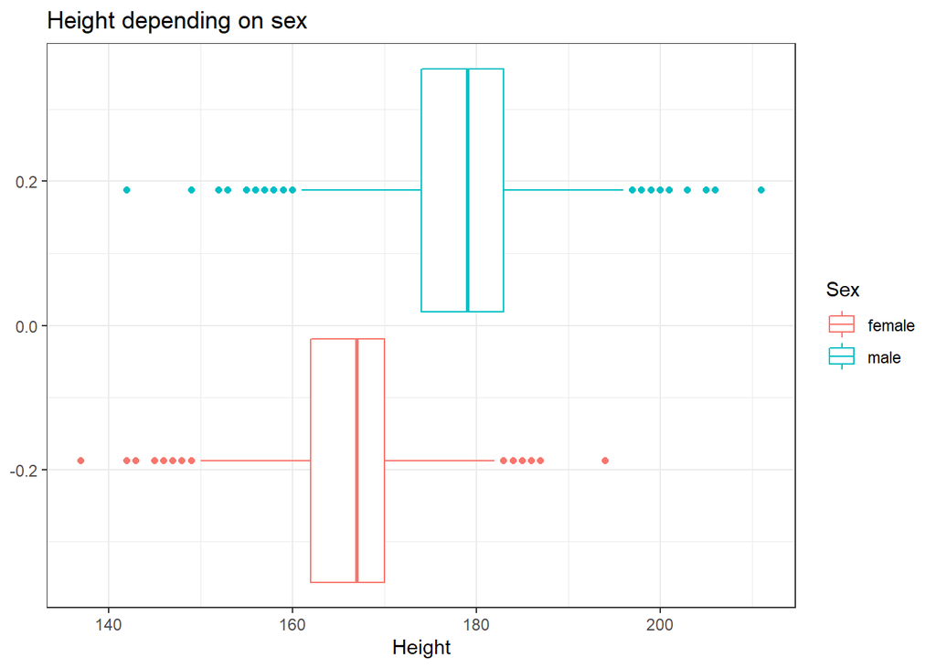

```r
df_for_plots_14 <- data_all %>%
  filter(Season == 'Winter') %>%
  select(Sex, Height, Weight, Age)
ggplot(df_for_plots_14, aes(Height, color=Sex)) +
  geom_boxplot() +
  scale_color_hue(labels = c("female", "male")) +
  theme_bw() +
  labs(title="Height depending on sex")
```

#### Weight comparison

Normality tests (work only for 3-5000 values, therefore we needed to create a slice):

```r
shapiro.test(males_winter$Weight[0:5000])
```

```
##
##  Shapiro-Wilk normality test
##
## data:  males_winter$Weight[0:5000]
## W = 0.97978, p-value < 2.2e-16
```

```r
shapiro.test(females_winter$Weight[0:5000])
```

```
##
##  Shapiro-Wilk normality test
##
## data:  females_winter$Weight[0:5000]
## W = 0.98853, p-value < 2.2e-16
```

1)W = 0.9798, p-value <2e-16 2)W = 0.9885, p-value <2e-16

Therefore, according to Shapiro-Wilk normality test, the distribution is not normal. Nevertheless, the results might be incorrect, according to the fact that we processed not the whole data frame.

Q-Q plots were drawn to check the normality:

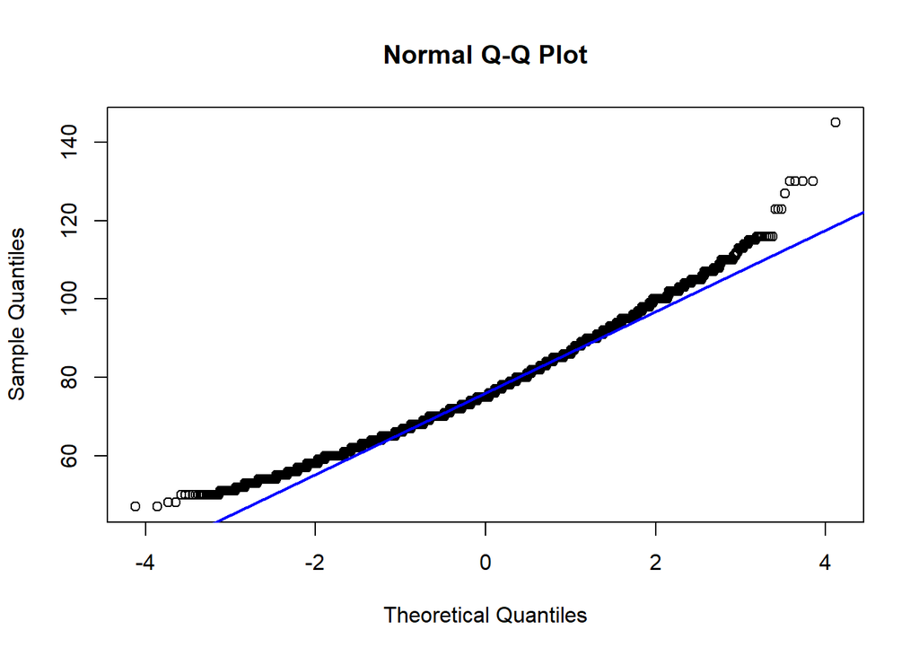

```r
qqnorm(males_winter$Weight)
qqline(males_winter$Weight, col = "blue", lwd = 2)
```

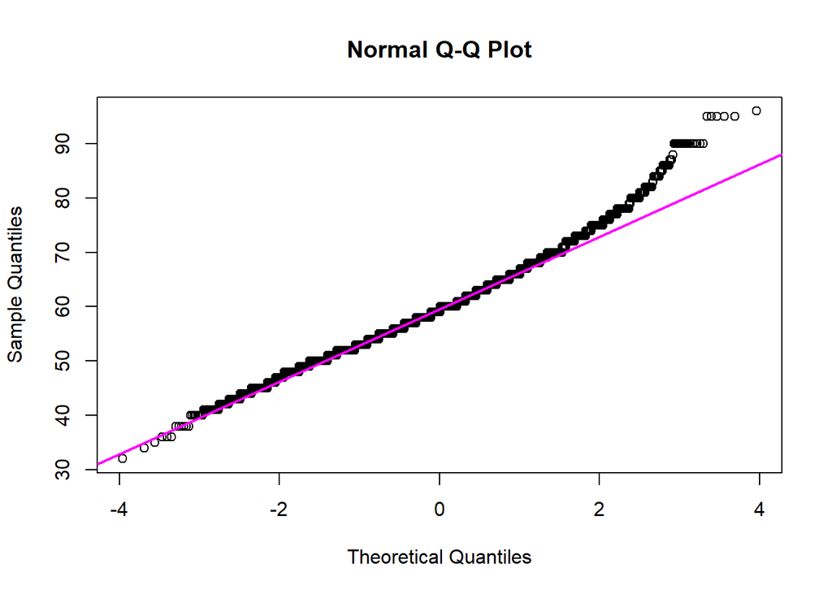

```r
qqnorm(females_winter$Weight)
qqline(females_winter$Weight, col = "magenta", lwd = 2)
```

Used F test to compare two variances:

```r
var.test(females_winter$Weight, males_winter$Weight)
```

```
##
##  F test to compare two variances
##
## data:  females_winter$Weight and males_winter$Weight
## F = 0.46688, num df = 13333, denom df = 26208, p-value < 2.2e-16
## alternative hypothesis: true ratio of variances is not equal to 1
## 95 percent confidence interval:
##  0.4533504 0.4808897
## sample estimates:
## ratio of variances
##          0.4668836
```

F = 0.4669, num df = 13333, denom df = 26208, p-value <2e-16

Therefore, there is a statistically significant difference between variances, and we need to use Welch Two Sample t-test.

Firstly, we used two-sided t-test:

```r
t.test(x=females_winter$Weight, y=males_winter$Weight, alternative = c("two.sided"), var.equal = FALSE)
```

```
##
##  Welch Two Sample t-test
##
## data:  females_winter$Weight and males_winter$Weight
## t = -187.85, df = 36296, p-value < 2.2e-16
## alternative hypothesis: true difference in means is not equal to 0
## 95 percent confidence interval:
##  -16.77517 -16.42871
## sample estimates:
## mean of x mean of y
##  59.75555  76.35749
```

t = -187.8, df = 36296, p-value <2e-16

The differences are statistically significant (p-value is below the chosen threshold of 0.05), therefore we can reject the null hypothesis (‘There is no difference between males and females weight’) in favor of the alternative hypothesis (‘There is a statistically significant difference between males and females weight’)

Secondly, we used one-tailed t-test:

```r
t.test(x=females_winter$Weight, y=males_winter$Weight, alternative = c("less"), var.equal = FALSE)
```

```
##
##  Welch Two Sample t-test
##
## data:  females_winter$Weight and males_winter$Weight
## t = -187.85, df = 36296, p-value < 2.2e-16
## alternative hypothesis: true difference in means is less than 0
## 95 percent confidence interval:
##       -Inf -16.45657
## sample estimates:
## mean of x mean of y
##  59.75555  76.35749
```

t = -187.8, df = 36296, p-value <2e-16

Again, the differences are statistically significant (p-value is below the chosen threshold of 0.05), therefore we can reject the null hypothesis (‘There is no difference between males and females weight’) in favor of the alternative hypothesis (‘Males are generally have greater weight than females’)

Boxplot was drawn to visualize the information:

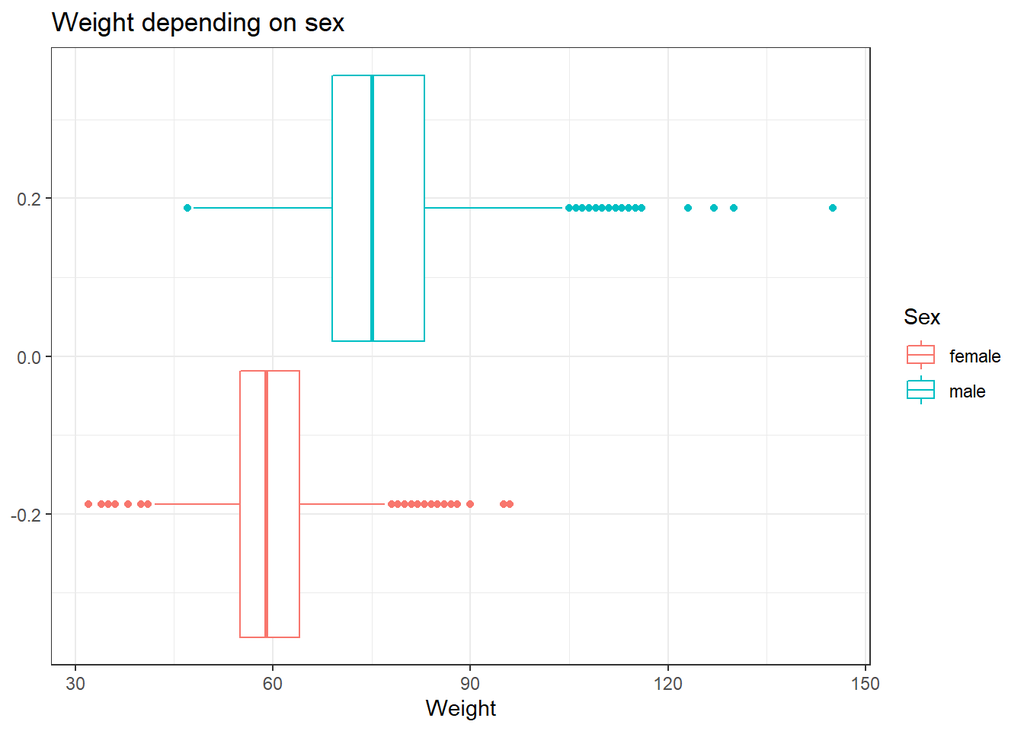

```r
ggplot(df_for_plots_14, aes(Weight, color=Sex)) +
  geom_boxplot() +
  scale_color_hue(labels = c("female", "male")) +
  theme_bw() +
  labs(title="Weight depending on sex")
```

#### Age comparison

Normality tests (work only for 3-5000 values, therefore we needed to create a slice):

```r
shapiro.test(males_winter$Age[0:5000])
```

```
##
##  Shapiro-Wilk normality test
##
## data:  males_winter$Age[0:5000]
## W = 0.96258, p-value < 2.2e-16
```

```r
shapiro.test(females_winter$Age[0:5000])
```

```
##
##  Shapiro-Wilk normality test
##
## data:  females_winter$Age[0:5000]
## W = 0.98101, p-value < 2.2e-16
```

1)W = 0.9626, p-value <2e-16 2)W = 0.981, p-value <2e-16

Therefore, according to Shapiro-Wilk normality test, the distribution is not normal. Nevertheless, the results might be incorrect, according to the fact that we processed not the whole data frame.

Q-Q plots were drawn to check the normality:

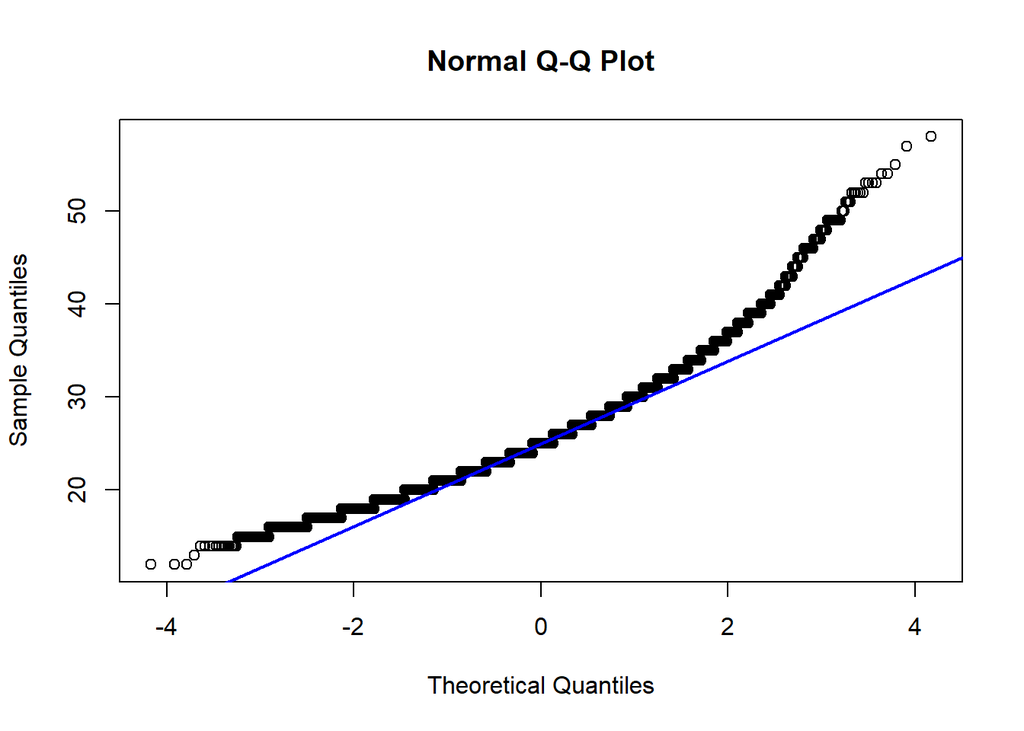

```r
qqnorm(males_winter$Age)
qqline(males_winter$Age, col = "blue", lwd = 2)
```

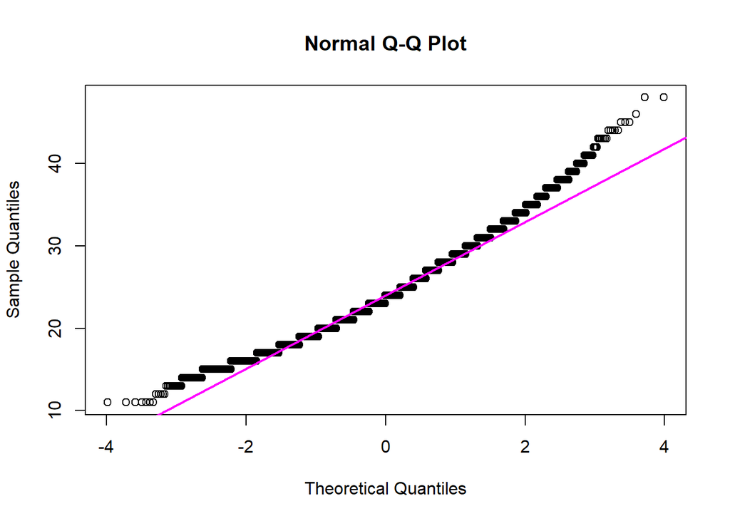

```r
qqnorm(females_winter$Age)
qqline(females_winter$Age, col = "magenta", lwd = 2)
```

Used F test to compare two variances:

```r
var.test(females_winter$Age, males_winter$Age)
```

```
##
##  F test to compare two variances
##
## data:  females_winter$Age and males_winter$Age
## F = 0.97635, num df = 15072, denom df = 33205, p-value = 0.08559
## alternative hypothesis: true ratio of variances is not equal to 1
## 95 percent confidence interval:
##  0.9501903 1.0033615
## sample estimates:
## ratio of variances
##          0.9763452
```

F = 0.9763, num df = 15072, denom df = 33205, p-value = 0.0856

Therefore, there is no statistically significant difference between variances (p-value > 0.05), and we need to use Student Two Sample t-test.

Firstly, we used two-sided t-test:

```r
t.test(x=females_winter$Age, y=males_winter$Age, alternative = c("two.sided"), var.equal = TRUE)
```

```
##
##  Two Sample t-test
##
## data:  females_winter$Age and males_winter$Age
## t = -32.095, df = 48277, p-value < 2.2e-16
## alternative hypothesis: true difference in means is not equal to 0
## 95 percent confidence interval:
##  -1.581206 -1.399193
## sample estimates:
## mean of x mean of y
##   24.0142   25.5044
```

t = -32.09, df = 48277, p-value <2e-16

The differences are statistically significant (p-value is below the chosen threshold of 0.05), therefore we can reject the null hypothesis (‘There is no difference between the age of male and female competitors’) in favor of the alternative hypothesis (‘There is a statistically significant difference between the age of male and female competitors’)

Secondly, we used one-tailed t-test:

```r
t.test(x=females_winter$Age, y=males_winter$Age, alternative = c("less"), var.equal = TRUE)
```

```
##
##  Two Sample t-test
##
## data:  females_winter$Age and males_winter$Age
## t = -32.095, df = 48277, p-value < 2.2e-16
## alternative hypothesis: true difference in means is less than 0
## 95 percent confidence interval:
##       -Inf -1.413825
## sample estimates:
## mean of x mean of y
##   24.0142   25.5044
```

t = -32.09, df = 48277, p-value <2e-16

Again, the differences are statistically significant (p-value is below the chosen threshold of 0.05), therefore we can reject the null hypothesis (‘There is no difference between between the age of male and female competitors’) in favor of the alternative hypothesis (‘Males competitors are generally older than female’)

Boxplot was drawn to visualize the information:

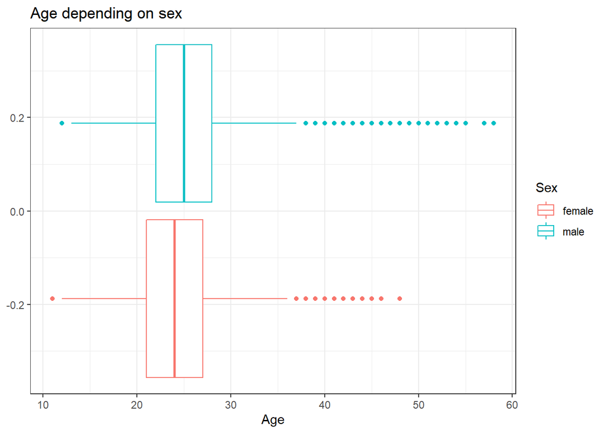

```r
ggplot(df_for_plots_14, aes(Age, color=Sex)) +
  geom_boxplot() +
  scale_color_hue(labels = c("female", "male")) +
  theme_bw() +
  labs(title="Age depending on sex")
```